# notebook slides

**Problem 3**: Make an ipython slideshow based on different vizualization graphs.

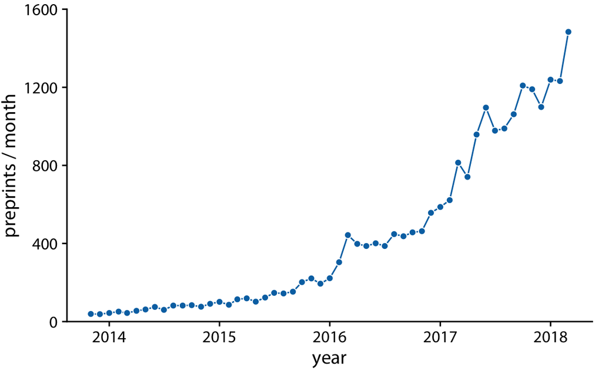

```python
#download and display images
from IPython.display import display, Image

display(Image(filename="images/time_series.png"))
```

**1D Time Series**  
This figure shows a variable plotted against time. It’s a 1D time series because the data has only one independent dimension (time) and one dependent value. The plot highlights how the value changes step by step, showing fluctuations and patterns.

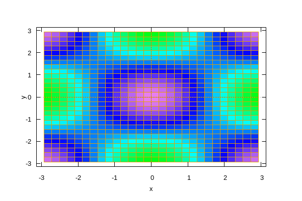

```python
display(Image(filename="images/2d_scalar.png"))
```

**2D Scalar Field** This figure represents a scalar field defined on a 2D plane. Each point in the plane has a scalar value (like temperature or pressure). The visualization uses color shading or contours to show how the scalar values vary across the space.

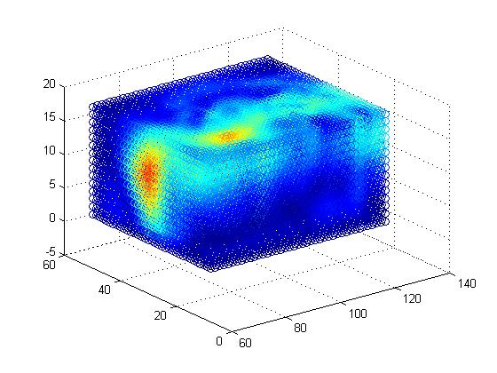

```python
display(Image(filename="images/3d_scalar.png"))
```

**3D Scalar Field** This figure shows scalar values distributed in three-dimensional space. Each location in the 3D volume is associated with a scalar, and the plot typically uses slices or surfaces to visualize how the values change in different regions.

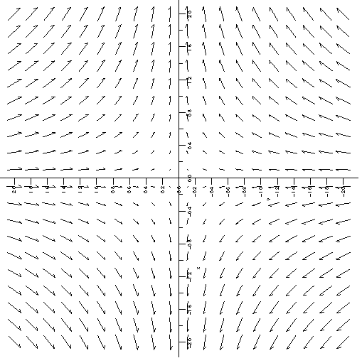

```python
display(Image(filename="images/2d_vector.png"))
```

**2D Vector Field** This figure shows a vector field in two dimensions. At each point in the plane, a vector (arrow) indicates both magnitude and direction. These types of plots are common for representing velocity fields in fluid flow or electromagnetic fields.

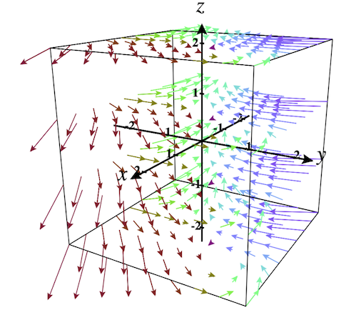

```python
display(Image(filename="images/3d_vector.png"))
```

**3D Vector Field** This figure extends the vector field idea into three dimensions. Each arrow represents a vector in 3D space, showing both direction and magnitude. Such plots are used for 3D flows, forces, or other physical vector quantities.

[figure not shown]

```python
display(Image(filename="images/graph.png"))
```

**Graph Structure** This figure shows a graph made of nodes and edges. Nodes represent entities, and edges represent relationships or connections between them. Graphs are used to model networks like social networks, transportation systems, or the web.

**Sources:**

- https://clauswilke.com/dataviz/time-series.html
- https://stackoverflow.com/questions/46570193/maxima-colorplot-of-2d-scalar-field-fx-y-aka-birds-view
- https://www.whitman.edu/mathematics/calculus_late_online/section18.01.html
- https://c3d.libretexts.org/CalcPlot3D/CalcPlot3D-Help/section-vectorfields.html
- https://neo4j.com/blog/developer/hands-on-graph-data-visualization/